# P1_template

Sameena Thabassum

January 18, 2017

Instructions: This is the template you may use to type up your responses to the exercises and the on your own questions. Within RStudeo, to produce a document that you can print out and turn in just click on Knit HTML above. All you need to do to complete the lab is to type up your BRIEF answers and the R code (when necessary) in the spaces provided below.

To use the min.css formatting, leave the css file mentioned in the YAML section of the document. Otherwise, I suggest a simple Bootstrap theme.

# Question 1

Classification is to prdict what class the variable belows to, whereas Regression predicts a continuous value. For example given a persons family history of diabetes, health condition,food habits we can predict if that person may have diabates in future(categorical) , this is classfication. Given a computers configuration and brand , one can predict its price(price), this is regression.

Regression and classification are similar as both of them predict a value depending on the other variable values

# Q2

The census data can be downloaded from the [UCI ML site](http://archive.ics.uci.edu/ml/datasets/Census+Income) and loaded using the `read.csv` command. Alternatively, it can be read directly from the UCI site (follow the example used in the Exploratory Analysis examples).

```r
adult <- read.csv("adult.data.txt",header=F, na.strings="?")
```

Inline r code can be inserted as 39.  
This can also be used in a table:

|  | Var 1 | Var 3 |
| --- | --- | --- |
| Mean | 38.5816468 | 1.897783710^{5} |
| Max | 90 | 1484705 |

## Q2a

Information on each variable:

- **Age**: Age is the age of an individual as reported by that person for the 1990 census; the value is continuous and reported in integer units of years.
- **Workclass**:Workclass is the workclass of an individual as reported by that person for the 1990 census;the value is reported in categoricaly {" ?“,” Federal-gov“,” Local-gov“,” Never-worked“,” Private“,” Self-emp-inc“,” Self-emp-not-inc“,” State-gov“,” Without-pay“}

```r
wc<-levels(adult$V2)
wc
```

```
## [1] " ?"                " Federal-gov"      " Local-gov"
## [4] " Never-worked"     " Private"          " Self-emp-inc"
## [7] " Self-emp-not-inc" " State-gov"        " Without-pay"
```

- **finalsamplingweight**:Shows the final sampling weight of an individual in the 1990 census.THe value is continuous and reported in integer.
- **education**:Shows the education of individual as reported by that person in the 1990 census. This is Categoricaly represented.
- **Educational Number**: Shows Educational number for the individual as reported by that person in for the 1990 census.Represented in integers.
- **Martial-status**:Tells about the martial status of the individual as reported by that person in 1990 census.

```r
ms<-levels(adult$V6)
ms
```

```
## [1] " Divorced"              " Married-AF-spouse"
## [3] " Married-civ-spouse"    " Married-spouse-absent"
## [5] " Never-married"         " Separated"
## [7] " Widowed"
```

- **Occupation**:Occupation of the individual as reported by that person in the census 1990.Represented categoricaly.‘?’ represents missing value.

```r
occ<-levels(adult$V7)
occ
```

```
##  [1] " ?"                 " Adm-clerical"      " Armed-Forces"
##  [4] " Craft-repair"      " Exec-managerial"   " Farming-fishing"
##  [7] " Handlers-cleaners" " Machine-op-inspct" " Other-service"
## [10] " Priv-house-serv"   " Prof-specialty"    " Protective-serv"
## [13] " Sales"             " Tech-support"      " Transport-moving"
```

- **Relationship**: Relationship of the person as reported by the person in 1990 census.Represented categoricaly

```r
rel<-levels(adult$V8)
rel
```

```
## [1] " Husband"        " Not-in-family"  " Other-relative" " Own-child"
## [5] " Unmarried"      " Wife"
```

- **Race**: Race of the person.Represented categoricaly

```r
race<-levels(adult$V9)
race
```

```
## [1] " Amer-Indian-Eskimo" " Asian-Pac-Islander" " Black"
## [4] " Other"              " White"
```

- **sex**: Sex of the person.Represented categoricaly in {male,female}

```r
sex<-levels(adult$V10)
sex
```

```
## [1] " Female" " Male"
```

- **Capitalgain**: Shows Capital gain of the person.Represented in integers.
- **Capitalloss**: Shows Capital loss of the person.Represented in integers.
- **hours-per-week**:Shows how many hours the individual spends working per week.represented in integers
- **native-country**:Tells about that native country of the individual.It is represented categoricaly.‘?’ represents missing value.

```r
nc<-levels(adult$V14)
nc
```

```
##  [1] " ?"                          " Cambodia"
##  [3] " Canada"                     " China"
##  [5] " Columbia"                   " Cuba"
##  [7] " Dominican-Republic"         " Ecuador"
##  [9] " El-Salvador"                " England"
## [11] " France"                     " Germany"
## [13] " Greece"                     " Guatemala"
## [15] " Haiti"                      " Holand-Netherlands"
## [17] " Honduras"                   " Hong"
## [19] " Hungary"                    " India"
## [21] " Iran"                       " Ireland"
## [23] " Italy"                      " Jamaica"
## [25] " Japan"                      " Laos"
## [27] " Mexico"                     " Nicaragua"
## [29] " Outlying-US(Guam-USVI-etc)" " Peru"
## [31] " Philippines"                " Poland"
## [33] " Portugal"                   " Puerto-Rico"
## [35] " Scotland"                   " South"
## [37] " Taiwan"                     " Thailand"
## [39] " Trinadad&Tobago"            " United-States"
## [41] " Vietnam"                    " Yugoslavia"
```

## Q2b

```r
missed<-function(x)
{
    total<-length(x)
    t<-table(x)
    td<-as.data.frame(t)
    a<-td[which(td[1,]==" ?"),2]
    if(length(a)==0)
    {
        print("NO '?' values")
    }
    else
    {
   per<-a/total
   per<-per*100
   print(per)
    }

}
```

Variable 1 Age

```r
missed(adult$V1)
```

```
## [1] "NO '?' values"
```

Variable 2 Workclass

```r
missed(adult$V2)
```

```
## [1] 5.638647
```

Variable 3 finalsamplingweight

```r
missed(adult$V3)
```

```
## [1] "NO '?' values"
```

Variable 4 education

```r
missed(adult$V4)
```

```
## [1] "NO '?' values"
```

Variable 5 Educational Number

```r
missed(adult$V5)
```

```
## [1] "NO '?' values"
```

Variable 6 Martial-status

```r
missed(adult$V6)
```

```
## [1] "NO '?' values"
```

Variable 7 Occupation

```r
missed(adult$V7)
```

```
## [1] 5.660146
```

Variable 8 Relationship

```r
missed(adult$V8)
```

```
## [1] "NO '?' values"
```

Variable 9 Race

```r
missed(adult$V9)
```

```
## [1] "NO '?' values"
```

Variable 10 sex

```r
missed(adult$V10)
```

```
## [1] "NO '?' values"
```

Variable 11 Capitalgain

```r
missed(adult$V11)
```

```
## [1] "NO '?' values"
```

Variable 12 Capitalloss

```r
missed(adult$V12)
```

```
## [1] "NO '?' values"
```

Variable 13 hours per week

```r
missed(adult$V13)
```

```
## [1] "NO '?' values"
```

Variable 14 native country

```r
missed(adult$V14)
```

```
## [1] 1.790486
```

Variable 15 classification label

```r
missed(adult$V15)
```

```
## [1] "NO '?' values"
```

## Q2c

V1 age: numerical. V2 workclass: Categorical V3 fnlwgt: numerical V4 education: Categorical V5 education-num: categorical V6 marital-status: Categorical. V7 occupation: Categorical v8 relationship: Categorical V9 race:Categorical V10 sex:Categorical V11 capital-gain: numerical V11 capital-loss: numerical V13 hours-per-week: numerical V14 native-country: categorical V15 Label:categorical

## Q2d(i)

For V1 age variable The number of unique values for V1(age) will be

```r
unqv1<-as.data.frame(table(adult$V1))
nrow(unqv1) #no of rows gives the no. of unique values
```

```
## [1] 73
```

For V13 hours-per-week variable

```r
unqv13<-as.data.frame(table(adult$V13))
nrow(unqv13) #no of rows gives the no. of unique values
```

```
## [1] 94
```

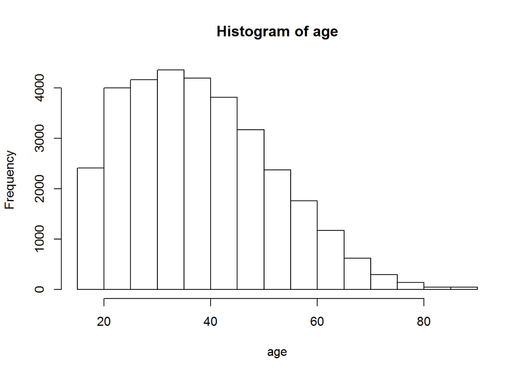

```r
hist(adult$V1,main="Histogram of age",xlab="age")
```

[figure not shown]

```r
hist(adult$V3,main="Histogram of Capital-Gain",breaks=50,xlab="Capital-Gain")
```

## Q2d(ii)

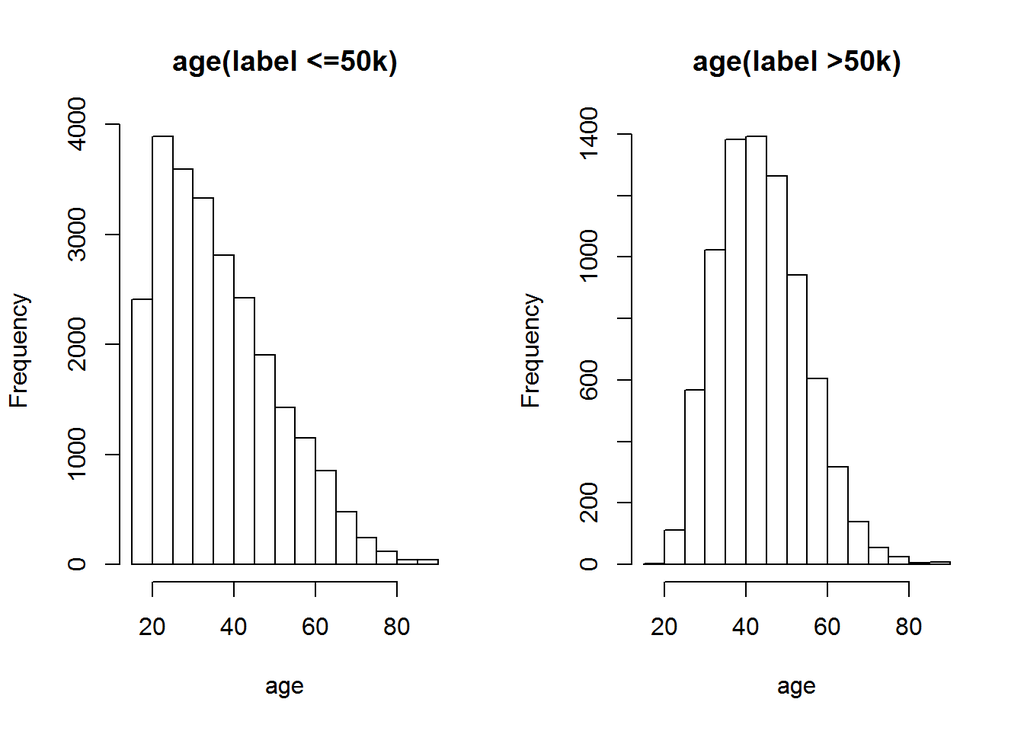

```r
age1<-adult[which(adult$V15==" <=50K"),1]
age2<-adult[which(adult$V15==" >50K"),1]
par(mfrow=c(1,2))
hist(age1,main="age(label <=50k)",xlab="age")
hist(age2,main="age(label >50k)",xlab="age")
```

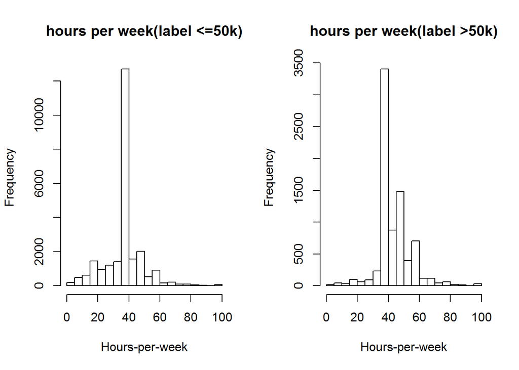

```r
hoursperweek1<-adult[which(adult$V15==" <=50K"),13]
hoursperweek2<-adult[which(adult$V15==" >50K"),13]
par(mfrow=c(1,2))
hist(hoursperweek1,main="hours per week(label <=50k)",xlab="Hours-per-week")
hist(hoursperweek2,main="hours per week(label >50k)",xlab="Hours-per-week")
```

## Q2d(iii)

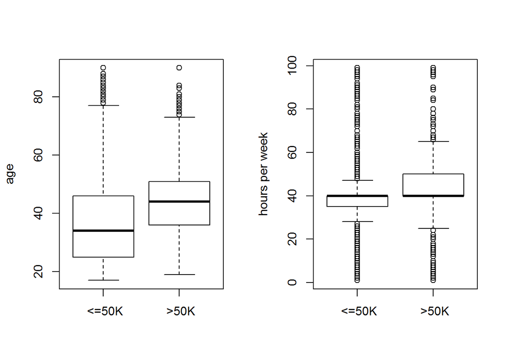

```r
par(mfrow=c(1,2))
boxplot(adult$V1~adult$V15,ylab="age")
boxplot(adult$V13~adult$V15,ylab="hours per week")
```

## Q2d(iV)

The number of people with label <=50 k has increased inconsistently with working hours per week . Maximum number of people with label <=50k are working for 35 to 40 hours and minimum number of people are working for 90 to 95 hours per week

The number of people with label >50K has increased inconsistently with working hours per week . Maximum number of people with label >50k are working for 35 to 40 hours and minimum number of people are working for 90 to 95 hours per week

BoxPlots for hours per week The median is people with lable <=50K are working for 40 hours per week. First quartile is from hours 28 to around 38 second quartile is from hours around 38 to 40. third quartile is around people working for 40 hours fourth quartile is from working hours 40 to 48

The median is people with lable >50K are working for 40 hours per week. First quartile is from hours 23 to 4o hours second quartile are people working around 40 hours third quartile is around people working for 40 to 48 hours fourth quartile is from working hours 48 to 65

## Q2e(i)

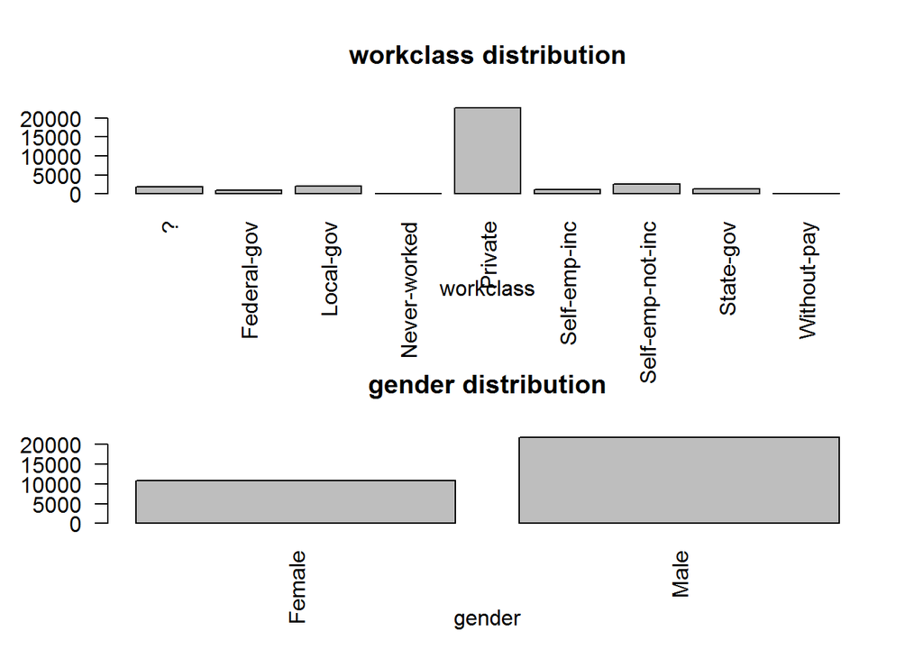

```r
par(mfrow=c(2,1))
barplot(table(adult$V2),main="workclass distribution",xlab="workclass",las=2)
barplot(table(adult$V10),main="gender distribution",xlab="gender",las=2)
```

## Q2e(ii)

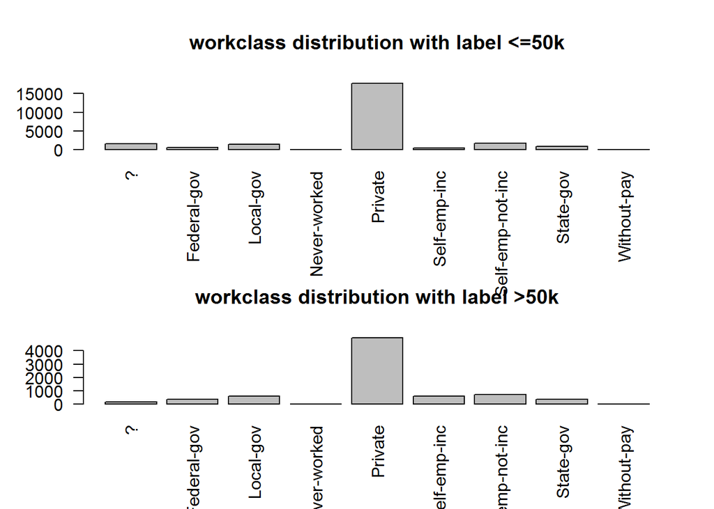

```r
par(mfrow=c(2,1))
barplot(table(adult[which(adult$V15==" <=50K"),2]),main="workclass distribution with label <=50k",las=2)
barplot(table(adult[which(adult$V15==" >50K"),2]),main="workclass distribution with label >50k",las=2)
```

[figure not shown]

```r
par(mfrow=c(2,1))
barplot(table(adult[which(adult$V15==" <=50K"),10]),main="education distribution with label <=50k",las=2)
barplot(table(adult[which(adult$V15==" >50K"),10]),main="Gender with label >50k",las=2)
```

## Q2f(i)

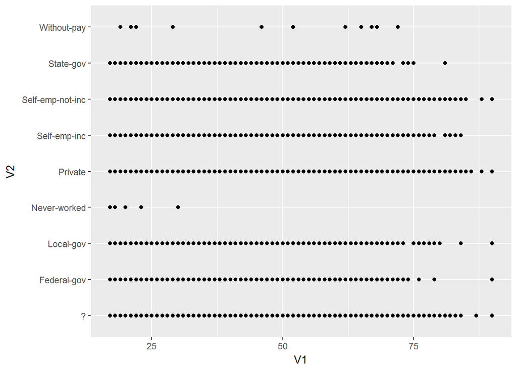

```r
library(ggplot2)
ggplot(adult,aes(V1,V2))+geom_point()
```

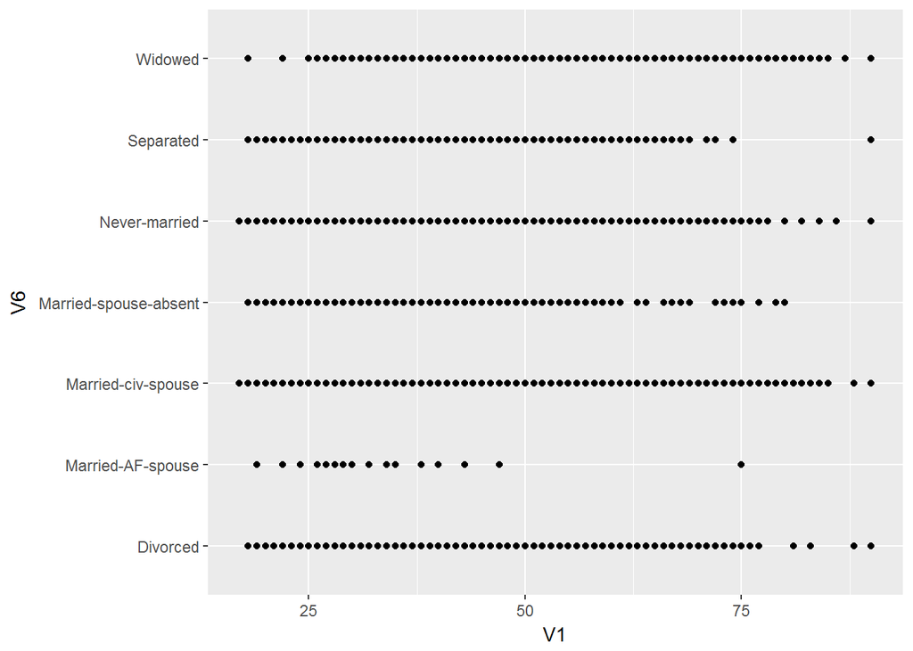

```r
library(ggplot2)
ggplot(adult,aes(V1,V6))+geom_point()
```

## Q2f(ii)

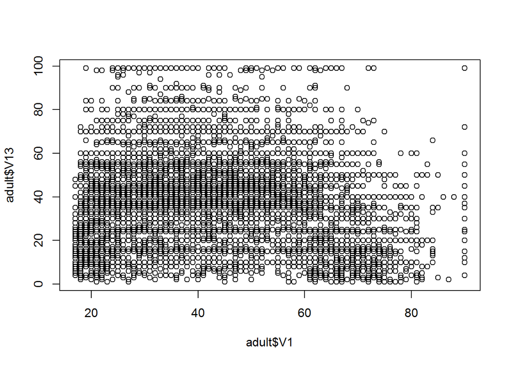

```r
plot(adult$V1,adult$V13)
```

Hours per week increased from age group 20-30 and was consistent upto 60 and from 60 it decreased

## Q3-a

mpg(mpg-miles per gallon) is quantitative, cylinders is quantitative, displacement is quantitative, horsepower is quantitative, weight is quantitative, acceleration is quantitative, year is quantitative, origin is quantitative, name is qualitative

## Q3-b

```r
auto<-read.csv("Auto.csv")
```

mode function

```r
mode<-function(x)
{
  tab<-table(x)
  a<-names(tab)[tab==max(tab)]
  print(a)
}
```

mpg

Mode:

```r
mode(auto$mpg)
```

```
## [1] "13"
```

Range:9, 46.6

Median:23

cylinders

Mode:

```r
mode(auto$cylinders)
```

```
## [1] "4"
```

Range:3, 8

Median:4

displacement

Mode:

```r
mode(auto$displacement)
```

```
## [1] "97"
```

Range:68, 455

Median:146

horsepower

HP<-as.character(auto$horsepower) #converting horsepower from factor to character HP[HP==“?”]<-0 #replacing “?” HP<-as.numeric(HP)

Mode:

```r
mode(HP)
```

```
## [1] "150"
```

Range:0, 230

Median:92

weight

Mode:

```r
mode(auto$weight)
```

```
## [1] "1985" "2130"
```

Range:1613, 5140

Median:2800

acceleration

Mode:

```r
mode(auto$acceleration)
```

```
## [1] "14.5"
```

Range:8, 24.8

Median:15.5

year

Mode:

```r
mode(auto$year)
```

```
## [1] "73"
```

Range:70, 82

Median:76

origin

Mode:

```r
mode(auto$origin)
```

```
## [1] "1"
```

Range:1, 3

Median:1

## Q3-c

displacement is numeric numeric

```r
DS<-auto$displacement
```

unique values of horsepower :130, 165, 150, 140, 198, 220, 215, 225, 190, 170, 160, 95, 97, 85, 88, 46, 87, 90, 113, 200, 210, 193, ?, 100, 105, 175, 153, 180, 110, 72, 86, 70, 76, 65, 69, 60, 80, 54, 208, 155, 112, 92, 145, 137, 158, 167, 94, 107, 230, 49, 75, 91, 122, 67, 83, 78, 52, 61, 93, 148, 129, 96, 71, 98, 115, 53, 81, 79, 120, 152, 102, 108, 68, 58, 149, 89, 63, 48, 66, 139, 103, 125, 133, 138, 135, 142, 77, 62, 132, 84, 64, 74, 116, 82 replacing “?” with 0

```r
HP<-as.character(auto$horsepower) #converting horsepower from factor to character
HP[HP=="?"]<-0 #replacing "?"
HP<-as.numeric(HP)
```

First quartile of displacement 104

37th percentile of displacement 120.52

89th percentile of displacement 350

First quartile of horsepower 75

37th percentile of horsepower 86

89th percentile of horsepower 152.44

## Q3-e

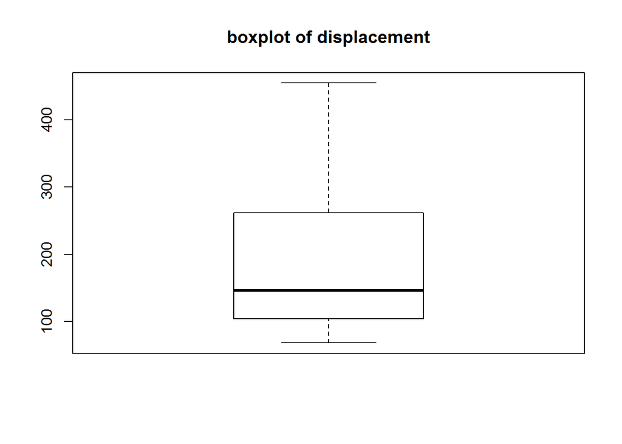

```r
boxplot(DS,main="boxplot of displacement")
```

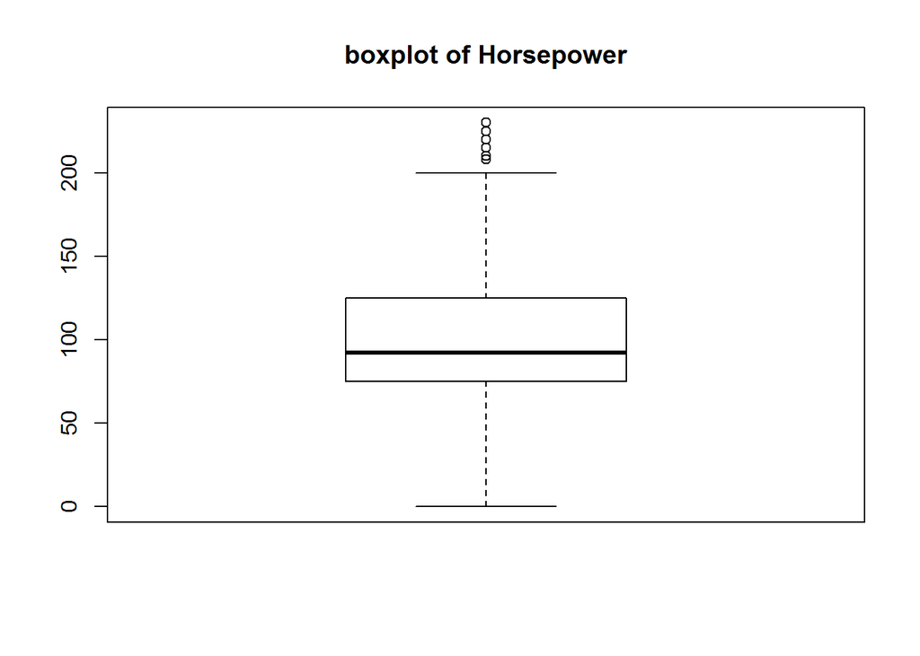

```r
boxplot(HP,main="boxplot of Horsepower")
```

## Q4-a(i)

For males

```r
mmatches<-read.csv("charting-m-matches.csv")
mstats<-read.csv("charting-m-stats-overview.csv")
m<-subset(mmatches,Tournament=="Australian Open"|Tournament=="French Open"|Tournament=="Wimbledon"|Tournament=="US Open")
mmerge<-merge(m,mstats,by="match_id")
mmerge$Date<-as.Date(mmerge$Date,"%Y%m%d")
mmerged<-subset(mmerge,Date>"2011-01-01")
mp1temp<-subset(mmerged,player==1)
mp2temp<-subset(mmerged,player==2)
mp1<-mp1temp[,c(1,2,7,8,17,18,20)]
mp2<-mp2temp[,c(1,3,7,8,17,18,20)]
mp1total<-subset(mp1,set=="Total")
mp2total<-subset(mp2,set=="Total")
colnames(mp1total)[colnames(mp1total)=="Player.1"]<-"player_name"
colnames(mp2total)[colnames(mp2total)=="Player.2"]<-"player_name"
mtotal<-rbind(mp1total,mp2total)
library("dtplyr")
groupm <- group_by(mtotal, player_name)
groupm2<-summarize(groupm, max.aces = max(aces))
#unique values
#head(groupm2[order(groupm2$max.aces,decreasing = TRUE),])
#without unique values
mtotal2<-mtotal[,c(2,7)]
head(mtotal2[order(mtotal2$aces,decreasing = TRUE),])
```

```
##        player_name aces
## 1347  Nick Kyrgios   37
## 1199  Nick Kyrgios   33
## 1364 Roger Federer   29
## 1466  Ivo Karlovic   29
## 1308 Tomas Berdych   25
## 1555 Bernard Tomic   25
```

For Female

```r
wmatches<-read.csv("charting-w-matches.csv")
wstats<-read.csv("charting-w-stats-overview.csv")
w<-subset(wmatches,Tournament=="Australian Open"|Tournament=="French Open"|Tournament=="Wimbledon"|Tournament=="US Open")
wmerge<-merge(w,wstats,by="match_id")

#wmerge$Date<-as.Date(wmerge$Date,"%Y%m%d")

wmerged<-subset(wmerge,Date>"2011-01-01")
wp1temp<-subset(wmerged,player==1)
wp2temp<-subset(wmerged,player==2)
wp1<-wp1temp[,c(1,2,7,8,17,18,20)]
wp2<-wp2temp[,c(1,3,7,8,17,18,20)]
wp1total<-subset(wp1,set=="Total")
wp2total<-subset(wp2,set=="Total")
colnames(wp1total)[colnames(wp1total)=="Player.1"]<-"player_name"
colnames(wp2total)[colnames(wp2total)=="Player.2"]<-"player_name"

wtotal<-rbind(wp1total,wp2total)
library("dtplyr")
groupw <- group_by(wtotal, player_name)
groupw2<-summarize(groupw, max.aces = max(aces))
#head(groupw2[order(groupw2$max.aces,decreasing = TRUE),])
#without unique values
wtotal2<-wtotal[,c(2,7)]
head(wtotal2[order(wtotal2$aces,decreasing = TRUE),])
```

```
##            player_name aces
## 1755 Kristyna Pliskova   31
## 1793   Maria Sharapova   21
## 677      Petra Kvitova   18
## 1386   Serena Williams   18
## 643    Serena Williams   17
## 1507   Serena Williams   17
```

## Q4-a(ii)

For Males

```r
mmatches<-read.csv("charting-m-matches.csv")
mstats<-read.csv("charting-m-stats-overview.csv")
m2merge<-merge(mmatches,mstats,by="match_id")
m2merge$Date<-as.Date(m2merge$Date,"%Y%m%d")
m2merged<-subset(m2merge,Date>"2015-01-01"&Date<="2015-12-31")
m2p1temp<-subset(m2merged,player==1)
m2p2temp<-subset(m2merged,player==2)
m2p1<-m2p1temp[,c(1,2,7,8,17,18,26,27)]
m2p2<-m2p1temp[,c(1,3,7,8,17,18,26,27)]

m2p1total<-subset(m2p1,set=="Total")
m2p2total<-subset(m2p2,set=="Total")
colnames(m2p1total)[colnames(m2p1total)=="Player.1"]<-"player_name"
colnames(m2p2total)[colnames(m2p2total)=="Player.2"]<-"player_name"

# library("dtplyr")
m2total<-rbind(m2p1total,m2p2total)
# group2m <- group_by(m2total, player_name)
# group2m2<-summarize(group2m, count.ply = count(player_name))
# group2m3<-subset(group2m2,count.ply.freq>="5")
# library(plyr)
m2total$per<-with(m2total,((bp_saved/bk_pts)*100))
#m2total100<-subset(m2total,per==100)
mcount<-as.data.frame(table(m2total$player_name))
mcount2<-subset(mcount,Freq>=5)
colnames(mcount2)[colnames(mcount2)=="Var1"]<-"player_name"
# m2totalcount<-count(m2total,c("player_name"))
# group2m3<-subset(group2m2,freq>=5)
#m2total$per<-with(m2total,((bp_saved/bk_pts)*100))
m2total2<-merge(mcount2,m2total,by="player_name")
m2total3<-m2total2[,c(1,10)]
#m2total4<-m2total3[order(m2total3$per,decreasing = TRUE),]
head(m2total3[order(m2total3$per,decreasing = TRUE),])
```

```
##      player_name per
## 17   Andy Murray 100
## 25   Andy Murray 100
## 38   Andy Murray 100
## 46 Bernard Tomic 100
## 60   Borna Coric 100
## 82  David Goffin 100
```

For females

```r
wmatches<-read.csv("charting-w-matches.csv")
wstats<-read.csv("charting-w-stats-overview.csv")
w2merge<-merge(wmatches,wstats,by="match_id")
#w2merge$Date<-as.Date(w2merge$Date,"%Y%m%d")
w2merged<-subset(w2merge,Date>"20150101"&Date<="20151231")
w2p1temp<-subset(w2merged,player==1)
w2p2temp<-subset(w2merged,player==2)
w2p1<-w2p1temp[,c(1,2,7,8,17,18,26,27)]
w2p2<-w2p1temp[,c(1,3,7,8,17,18,26,27)]


w2p1total<-subset(w2p1,set=="Total")
w2p2total<-subset(w2p2,set=="Total")
colnames(w2p1total)[colnames(w2p1total)=="Player.1"]<-"player_name"
colnames(w2p2total)[colnames(w2p2total)=="Player.2"]<-"player_name"

# library("dtplyr")
w2total<-rbind(w2p1total,w2p2total)
# group2m <- group_by(m2total, player_name)
# group2m2<-summarize(group2m, count.ply = count(player_name))
# group2m3<-subset(group2m2,count.ply.freq>="5")
# library(plyr)
w2total$per<-with(w2total,((bp_saved/bk_pts)*100))
#m2total100<-subset(m2total,per==100)
wcount<-as.data.frame(table(w2total$player_name))
wcount2<-subset(wcount,Freq>=5)
colnames(wcount2)[colnames(wcount2)=="Var1"]<-"player_name"
# m2totalcount<-count(m2total,c("player_name"))
# group2m3<-subset(group2m2,freq>=5)
#m2total$per<-with(m2total,((bp_saved/bk_pts)*100))
w2total2<-merge(wcount2,w2total,by="player_name")
w2total3<-w2total2[,c(1,10)]
#m2total4<-m2total3[order(m2total3$per,decreasing = TRUE),]
head(w2total3[order(w2total3$per,decreasing = TRUE),])
```

```
##            player_name per
## 9  Agnieszka Radwanska 100
## 27 Agnieszka Radwanska 100
## 28 Agnieszka Radwanska 100
## 32 Alison Van Uytvanck 100
## 36 Alison Van Uytvanck 100
## 48        Ana Ivanovic 100
```